# PigWeb: cortisol

Author

Liza Moscoviche & Anja Eggert

Published

April 17, 2025

# Libraries

```r
library(kableExtra)
library(tidyverse)
library(rstatix)
library(lmerTest)
library(car)
library(performance)
library(emmeans)
```

# Scripts, etc.

```r
contr = lmerControl(optimizer   = "bobyqa",
                    optCtrl     = list(maxfun = 10000000),
                    calc.derivs = FALSE)
```

```r
my_theme = theme_classic() +
  theme(text = element_text(family = "sans"),
        plot.title   = element_text(face = "plain", size = 16),
        axis.title   = element_text(face = "bold", size = 16),
        axis.text    = element_text(size = 14, angle = 0, vjust = 0.5),
        legend.title = element_text(face = "bold", size = 16),
        legend.text  = element_text(face = "plain", size = 16),
        strip.text   = element_text(size = 16),
        legend.position = "top",
        panel.grid.major = element_blank(),
        panel.grid.minor = element_blank())
```

```r
set.seed(1989)
```

# Data

Analysis of cortisol data from all 4 institutes, positive and negative context and pre and post samples.

## Read data

```r
dat <- read_csv("./data/PigWeb-physiology.csv",
                show_col_types = FALSE)
```

## Process data

```r
dat <- dat |>
  mutate(across(where(is.character), as.factor)) |>
  mutate(date           = dmy(date),
         date.f         = as.factor(date),
         institute      = fct_relevel(institute, "AU", "INRAE", "IRTA", "WUR"),
         institute      = relevel(institute, ref = "AU"),
         sample         = relevel(sample,    ref = "pre"),
         context        = relevel(context,   ref = "negative"),
         time_collect   = hour(time) + minute(time)/60,
         time_collect.z = as.vector(scale(time_collect)),
         space_allowance       = pen_space_m2/(group_weight_kg^0.66),
         space_allowance.log.z = as.vector(scale(log(space_allowance))))
```

# Descriptive statistics across context

Pooled for all institutes:

```r
dat |>
  group_by(context, sample) |>
  rstatix::get_summary_stats(cort_ngmL,
                             show = c("median","q1", "q3")) |>
  ungroup() |>
  arrange(variable) |>
  mutate(across(c(median, q1, q3), ~ round(., 2))) |>
  kable(caption = "Text for Fig. 4") |>
  kable_styling(bootstrap_options = c("striped", "hover"), font_size = 12) |>
  scroll_box()
```

Text for Fig. 4

| sample | context | variable | n | median | q1 | q3 |
| --- | --- | --- | --- | --- | --- | --- |
| pre | negative | cort_ngmL | 122 | 3.99 | 1.81 | 6.42 |
| post | negative | cort_ngmL | 120 | 5.05 | 2.78 | 8.74 |
| pre | positive | cort_ngmL | 121 | 3.68 | 1.17 | 7.60 |
| post | positive | cort_ngmL | 117 | 3.47 | 1.60 | 6.78 |

# Cortisol model: all 4 institutes

Model with 2 interactions of fixed effects and random intercepts but constant slope.

Full model:

```r
mod.cort <- lmerTest::lmer(log(cort_ngmL) ~
                             sample * context +
                             sample * institute +
                             space_allowance.log.z +
                             time_collect.z +
                             (1|date) +
                             (1|pig_group_unique) +
                             (1|pig_id_unique),
                           data    = dat,
                           REML    = FALSE,
                           control = contr)
```

Reduced model, without interactions and without `sample`, `context` and `institute`:

```r
mod.cort.red <- lmerTest::lmer(log(cort_ngmL) ~
                                 space_allowance.log.z +
                                 time_collect.z +
                                 (1|date) +
                                 (1|pig_group_unique) +
                                 (1|pig_id_unique),
                               data    = dat,
                               REML    = FALSE,
                               control = contr)
```

Comparison of reduced and full model:

```r
anova(mod.cort.red, mod.cort, test = "Chisq")
```

```
Data: dat
Models:
mod.cort.red: log(cort_ngmL) ~ space_allowance.log.z + time_collect.z + (1 | date) + (1 | pig_group_unique) + (1 | pig_id_unique)
mod.cort: log(cort_ngmL) ~ sample * context + sample * institute + space_allowance.log.z + time_collect.z + (1 | date) + (1 | pig_group_unique) + (1 | pig_id_unique)
             npar    AIC    BIC  logLik deviance  Chisq Df Pr(>Chisq)
mod.cort.red    7 924.81 954.03 -455.41   910.81
mod.cort       16 842.77 909.55 -405.38   810.77 100.04  9  < 2.2e-16 ***
---
Signif. codes:  0 '***' 0.001 '**' 0.01 '*' 0.05 '.' 0.1 ' ' 1
```

## Final model

Get effect estimates and standard errors of the model fitted with ML (`REML = FALSE`):

```r
round(summary(mod.cort)$coefficients, 2)
```

```
                           Estimate Std. Error     df t value Pr(>|t|)
(Intercept)                    1.90       0.18  50.47   10.85     0.00
samplepost                    -0.07       0.12 348.78   -0.58     0.56
contextpositive                0.06       0.09 179.07    0.60     0.55
instituteINRAE                 0.04       0.22  40.06    0.17     0.87
instituteIRTA                 -0.62       0.28  30.02   -2.25     0.03
instituteWUR                  -1.70       0.21  47.45   -8.09     0.00
space_allowance.log.z         -0.21       0.07  18.01   -3.05     0.01
time_collect.z                -0.03       0.04 228.31   -0.63     0.53
samplepost:contextpositive    -0.32       0.09 344.03   -3.49     0.00
samplepost:instituteINRAE      0.37       0.14 346.79    2.60     0.01
samplepost:instituteIRTA       0.22       0.16 353.37    1.38     0.17
samplepost:instituteWUR        0.75       0.14 345.99    5.49     0.00
```

Get *p* values of fixed effects and interactions of the model fitted with REML (`REML = TRUE`). Using `drop1()`, for factors that are part of interactions, the main effect cannot be tested. In this case `car::Anova` can be used:

```r
round(drop1(mod.cort |> update(REML = TRUE),
            test = "Chisq"), 3)
```

[output not shown]

```r
car::Anova(mod.cort |> update(REML = TRUE),
           test.statistic = "Chisq",
           type = 3) # as with interaction, otherwise set type = 2
```

```
Analysis of Deviance Table (Type III Wald chisquare tests)

Response: log(cort_ngmL)
                        Chisq Df Pr(>Chisq)
(Intercept)           97.4683  1  < 2.2e-16 ***
sample                 0.3177  1  0.5729929
context                0.3005  1  0.5835603
institute             89.0193  3  < 2.2e-16 ***
space_allowance.log.z  6.0211  1  0.0141356 *
time_collect.z         0.4739  1  0.4912016
sample:context        12.0065  1  0.0005302 ***
sample:institute      35.9495  3  7.675e-08 ***
---
Signif. codes:  0 '***' 0.001 '**' 0.01 '*' 0.05 '.' 0.1 ' ' 1
```

```r
car::Anova(mod.cort |> update(REML = TRUE),
           test.statistic = "F",
           type = 3) # as with interaction, otherwise set type = 2
```

```
Analysis of Deviance Table (Type III Wald F tests with Kenward-Roger df)

Response: log(cort_ngmL)
                            F Df Df.res    Pr(>F)
(Intercept)           97.1365  1  33.56 1.944e-11 ***
sample                 0.3174  1 341.92 0.5735494
context                0.2849  1 174.63 0.5942053
institute             29.5511  3  23.79 3.406e-08 ***
space_allowance.log.z  5.8922  1  13.17 0.0302620 *
time_collect.z         0.4541  1 228.16 0.5010728
sample:context        12.0027  1 337.39 0.0005998 ***
sample:institute      11.9699  3 343.69 1.794e-07 ***
---
Signif. codes:  0 '***' 0.001 '**' 0.01 '*' 0.05 '.' 0.1 ' ' 1
```

## Model diagnostics

```r
performance::check_model(mod.cort)
```

[output not shown]

## Emmeans

```r
mod.cort.emm1 <- emmeans(mod.cort,
                         pairwise ~ institute,
                         data    = dat,
                         adjust  = "tukey",
                         lmer.df = "satterthwaite",
                         type    = "response")

mod.cort.emm1
```

```
$emmeans
 institute response    SE   df lower.CL upper.CL
 AU            6.14 0.986 36.9     4.44     8.50
 INRAE         7.68 1.070 26.1     5.77    10.22
 IRTA          3.68 0.738 20.6     2.42     5.59
 WUR           1.62 0.191 39.0     1.28     2.06

Results are averaged over the levels of: sample, context
Degrees-of-freedom method: satterthwaite
Confidence level used: 0.95
Intervals are back-transformed from the log scale

$contrasts
 contrast     ratio    SE   df null t.ratio p.value
 AU / INRAE    0.80 0.170 32.3    1  -1.053  0.7200
 AU / IRTA     1.67 0.442 25.4    1   1.934  0.2393
 AU / WUR      3.78 0.752 37.9    1   6.685  <.0001
 INRAE / IRTA  2.09 0.509 21.0    1   3.015  0.0309
 INRAE / WUR   4.73 0.866 32.7    1   8.479  <.0001
 IRTA / WUR    2.26 0.536 26.9    1   3.457  0.0093

Results are averaged over the levels of: sample, context
Degrees-of-freedom method: satterthwaite
P value adjustment: tukey method for comparing a family of 4 estimates
Tests are performed on the log scale
```

```r
mod.cort.emm1$contrasts %>% confint()
```

```
 contrast     ratio    SE   df lower.CL upper.CL
 AU / INRAE    0.80 0.170 32.3    0.450     1.42
 AU / IRTA     1.67 0.442 25.4    0.806     3.46
 AU / WUR      3.78 0.752 37.9    2.215     6.45
 INRAE / IRTA  2.09 0.509 21.0    1.057     4.12
 INRAE / WUR   4.73 0.866 32.7    2.879     7.76
 IRTA / WUR    2.26 0.536 26.9    1.185     4.33

Results are averaged over the levels of: sample, context
Degrees-of-freedom method: satterthwaite
Confidence level used: 0.95
Conf-level adjustment: tukey method for comparing a family of 4 estimates
Intervals are back-transformed from the log scale
```

```r
mod.cort.emm2 <- emmeans(mod.cort,
                         pairwise ~ sample|institute,
                         data    = dat,
                         adjust  = "tukey",
                         lmer.df = "satterthwaite",
                         type    = "response")

mod.cort.emm2
```

```
$emmeans
institute = AU:
 sample response    SE   df lower.CL upper.CL
 pre        6.89 1.180 47.7    4.880     9.72
 post       5.47 0.930 46.3    3.890     7.71

institute = INRAE:
 sample response    SE   df lower.CL upper.CL
 pre        7.15 1.040 31.7    5.312     9.63
 post       8.24 1.200 31.3    6.123    11.09

institute = IRTA:
 sample response    SE   df lower.CL upper.CL
 pre        3.70 0.776 24.3    2.402     5.70
 post       3.65 0.758 23.6    2.381     5.61

institute = WUR:
 sample response    SE   df lower.CL upper.CL
 pre        1.25 0.154 46.1    0.979     1.60
 post       2.10 0.262 48.4    1.637     2.70

Results are averaged over the levels of: context
Degrees-of-freedom method: satterthwaite
Confidence level used: 0.95
Intervals are back-transformed from the log scale

$contrasts
institute = AU:
 contrast   ratio     SE  df null t.ratio p.value
 pre / post 1.258 0.1450 351    1   1.989  0.0475

institute = INRAE:
 contrast   ratio     SE  df null t.ratio p.value
 pre / post 0.868 0.0758 358    1  -1.619  0.1063

institute = IRTA:
 contrast   ratio     SE  df null t.ratio p.value
 pre / post 1.013 0.1140 375    1   0.111  0.9119

institute = WUR:
 contrast   ratio     SE  df null t.ratio p.value
 pre / post 0.596 0.0446 350    1  -6.918  <.0001

Results are averaged over the levels of: context
Degrees-of-freedom method: satterthwaite
Tests are performed on the log scale
```

```r
mod.cort.emm2$contrasts %>% confint()
```

```
institute = AU:
 contrast   ratio     SE  df lower.CL upper.CL
 pre / post 1.258 0.1450 351    1.003     1.58

institute = INRAE:
 contrast   ratio     SE  df lower.CL upper.CL
 pre / post 0.868 0.0758 358    0.731     1.03

institute = IRTA:
 contrast   ratio     SE  df lower.CL upper.CL
 pre / post 1.013 0.1140 375    0.812     1.26

institute = WUR:
 contrast   ratio     SE  df lower.CL upper.CL
 pre / post 0.596 0.0446 350    0.514     0.69

Results are averaged over the levels of: context
Degrees-of-freedom method: satterthwaite
Confidence level used: 0.95
Intervals are back-transformed from the log scale
```

```r
mod.cort.emm3 <- emmeans(mod.cort,
                         pairwise ~ institute|sample,
                         data    = dat,
                         adjust  = "tukey",
                         lmer.df = "satterthwaite",
                         type    = "response")

mod.cort.emm3
```

```
$emmeans
sample = pre:
 institute response    SE   df lower.CL upper.CL
 AU            6.89 1.180 47.7    4.880     9.72
 INRAE         7.15 1.040 31.7    5.312     9.63
 IRTA          3.70 0.776 24.3    2.402     5.70
 WUR           1.25 0.154 46.1    0.979     1.60

sample = post:
 institute response    SE   df lower.CL upper.CL
 AU            5.47 0.930 46.3    3.890     7.71
 INRAE         8.24 1.200 31.3    6.123    11.09
 IRTA          3.65 0.758 23.6    2.381     5.61
 WUR           2.10 0.262 48.4    1.637     2.70

Results are averaged over the levels of: context
Degrees-of-freedom method: satterthwaite
Confidence level used: 0.95
Intervals are back-transformed from the log scale

$contrasts
sample = pre:
 contrast     ratio    SE   df null t.ratio p.value
 AU / INRAE   0.963 0.216 40.1    1  -0.169  0.9982
 AU / IRTA    1.861 0.514 30.0    1   2.247  0.1338
 AU / WUR     5.494 1.160 47.5    1   8.094  <.0001
 INRAE / IRTA 1.933 0.490 24.5    1   2.598  0.0695
 INRAE / WUR  5.706 1.090 39.2    1   9.081  <.0001
 IRTA / WUR   2.952 0.730 31.8    1   4.380  0.0007

sample = post:
 contrast     ratio    SE   df null t.ratio p.value
 AU / INRAE   0.664 0.149 40.0    1  -1.827  0.2762
 AU / IRTA    1.498 0.414 30.1    1   1.463  0.4716
 AU / WUR     2.602 0.547 47.2    1   4.552  0.0002
 INRAE / IRTA 2.254 0.571 24.5    1   3.210  0.0181
 INRAE / WUR  3.917 0.751 39.4    1   7.120  <.0001
 IRTA / WUR   1.737 0.423 30.5    1   2.267  0.1284

Results are averaged over the levels of: context
Degrees-of-freedom method: satterthwaite
P value adjustment: tukey method for comparing a family of 4 estimates
Tests are performed on the log scale
```

```r
mod.cort.emm3$contrasts %>% confint()
```

```
sample = pre:
 contrast     ratio    SE   df lower.CL upper.CL
 AU / INRAE   0.963 0.216 40.1    0.528     1.75
 AU / IRTA    1.861 0.514 30.0    0.878     3.95
 AU / WUR     5.494 1.160 47.5    3.137     9.62
 INRAE / IRTA 1.933 0.490 24.5    0.961     3.89
 INRAE / WUR  5.706 1.090 39.2    3.411     9.54
 IRTA / WUR   2.952 0.730 31.8    1.511     5.77

sample = post:
 contrast     ratio    SE   df lower.CL upper.CL
 AU / INRAE   0.664 0.149 40.0    0.365     1.21
 AU / IRTA    1.498 0.414 30.1    0.707     3.17
 AU / WUR     2.602 0.547 47.2    1.487     4.55
 INRAE / IRTA 2.254 0.571 24.5    1.122     4.53
 INRAE / WUR  3.917 0.751 39.4    2.342     6.55
 IRTA / WUR   1.737 0.423 30.5    0.896     3.37

Results are averaged over the levels of: context
Degrees-of-freedom method: satterthwaite
Confidence level used: 0.95
Conf-level adjustment: tukey method for comparing a family of 4 estimates
Intervals are back-transformed from the log scale
```

```r
mod.cort.emm4 <- emmeans(mod.cort,
                         pairwise ~ sample|context,
                         data    = dat,
                         adjust  = "tukey",
                         lmer.df = "satterthwaite",
                         type    = "response")

mod.cort.emm4
```

```
$emmeans
context = negative:
 sample response    SE   df lower.CL upper.CL
 pre        3.78 0.361 55.0     3.12     4.58
 post       4.91 0.467 54.4     4.06     5.94

context = positive:
 sample response    SE   df lower.CL upper.CL
 pre        4.00 0.369 45.7     3.32     4.82
 post       3.79 0.347 44.5     3.15     4.56

Results are averaged over the levels of: institute
Degrees-of-freedom method: satterthwaite
Confidence level used: 0.95
Intervals are back-transformed from the log scale

$contrasts
context = negative:
 contrast   ratio     SE  df null t.ratio p.value
 pre / post 0.769 0.0531 366    1  -3.797  0.0002

context = positive:
 contrast   ratio     SE  df null t.ratio p.value
 pre / post 1.055 0.0737 371    1   0.765  0.4450

Results are averaged over the levels of: institute
Degrees-of-freedom method: satterthwaite
Tests are performed on the log scale
```

```r
mod.cort.emm4$contrasts %>% confint()
```

```
context = negative:
 contrast   ratio     SE  df lower.CL upper.CL
 pre / post 0.769 0.0531 366    0.672    0.881

context = positive:
 contrast   ratio     SE  df lower.CL upper.CL
 pre / post 1.055 0.0737 371    0.919    1.210

Results are averaged over the levels of: institute
Degrees-of-freedom method: satterthwaite
Confidence level used: 0.95
Intervals are back-transformed from the log scale
```

# Cortisol model: only 3 institutes, without WUR

Model with interactions of fixed effects and random intercepts but constant slope.

Full model:

```r
mod.cort.noWUR <- lmerTest::lmer(log(cort_ngmL) ~
                                   sample * context +
                                   sample * institute +
                                   space_allowance.log.z +
                                   time_collect.z +
                                   (1|date) +
                                   (1|pig_group_unique) +
                                   (1|pig_id_unique),
                                 data = dat |>
                                   dplyr::filter(institute != "WUR") |>
                                   droplevels(),
                                 REML    = FALSE,
                                 control = contr)
```

Reduced model, without interactions and without `sample`, `context` and `institute`:

```r
mod.cort.noWUR.red <- lmerTest::lmer(log(cort_ngmL) ~
                                       space_allowance.log.z +
                                       time_collect.z +
                                       (1|date) +
                                       (1|pig_group_unique) +
                                       (1|pig_id_unique),
                                     data = dat |>
                                       dplyr::filter(institute != "WUR") |>
                                       droplevels(),
                                     REML    = FALSE,
                                     control = contr)
```

Comparison of reduced and full model:

```r
anova(mod.cort.noWUR.red, mod.cort.noWUR, test = "Chisq")
```

```
Data: droplevels(dplyr::filter(dat, institute != "WUR"))
Models:
mod.cort.noWUR.red: log(cort_ngmL) ~ space_allowance.log.z + time_collect.z + (1 | date) + (1 | pig_group_unique) + (1 | pig_id_unique)
mod.cort.noWUR: log(cort_ngmL) ~ sample * context + sample * institute + space_allowance.log.z + time_collect.z + (1 | date) + (1 | pig_group_unique) + (1 | pig_id_unique)
                   npar    AIC    BIC  logLik deviance  Chisq Df Pr(>Chisq)
mod.cort.noWUR.red    7 446.26 472.21 -216.13   432.26
mod.cort.noWUR       14 439.11 491.01 -205.56   411.11 21.145  7   0.003562 **
---
Signif. codes:  0 '***' 0.001 '**' 0.01 '*' 0.05 '.' 0.1 ' ' 1
```

## Final model

Get effect estimates and standard errors of the model fitted with ML (`REML = FALSE`):

```r
round(summary(mod.cort.noWUR)$coefficients, 2)
```

```
                           Estimate Std. Error     df t value Pr(>|t|)
(Intercept)                    1.81       0.21  41.94    8.60     0.00
samplepost                    -0.10       0.12 244.72   -0.78     0.44
contextpositive                0.10       0.09 154.01    1.11     0.27
instituteINRAE                 0.09       0.22  26.30    0.39     0.70
instituteIRTA                 -0.32       0.41  19.78   -0.79     0.44
space_allowance.log.z         -0.02       0.20  19.06   -0.12     0.90
time_collect.z                -0.03       0.18  61.26   -0.19     0.85
samplepost:contextpositive    -0.27       0.09 214.65   -2.83     0.01
samplepost:instituteINRAE      0.37       0.12 218.31    3.16     0.00
samplepost:instituteIRTA       0.22       0.18 167.02    1.24     0.22
```

Get *p* values of fixed effects and interactions of the model fitted with REML (`REML = TRUE`). Using `drop1()`, for factors that are part of interactions, the main effect cannot be tested. In this case `car::Anova` can be used:

```r
round(drop1(mod.cort.noWUR |> update(REML = TRUE),
            test = "Chisq"), 3)
```

```
Single term deletions using Satterthwaite's method:

Model:
log(cort_ngmL) ~ sample * context + sample * institute + space_allowance.log.z + time_collect.z + (1 | date) + (1 | pig_group_unique) + (1 | pig_id_unique)
                      Sum Sq Mean Sq NumDF   DenDF F value Pr(>F)
space_allowance.log.z  0.003   0.003     1  11.530   0.016  0.900
time_collect.z         0.026   0.026     1  54.843   0.155  0.696
sample:context         1.312   1.312     1 210.720   7.802  0.006 **
sample:institute       1.668   0.834     2 203.393   4.960  0.008 **
---
Signif. codes:  0 '***' 0.001 '**' 0.01 '*' 0.05 '.' 0.1 ' ' 1
```

```r
car::Anova(mod.cort.noWUR |> update(REML = TRUE),
           test.statistic = "Chisq",
           type = 3) # as with interaction, otherwise set type = 2
```

```
Analysis of Deviance Table (Type III Wald chisquare tests)

Response: log(cort_ngmL)
                        Chisq Df Pr(>Chisq)
(Intercept)           59.3464  1  1.322e-14 ***
sample                 0.4204  1   0.516731
context                0.7893  1   0.374310
institute              1.2299  2   0.540656
space_allowance.log.z  0.0165  1   0.897809
time_collect.z         0.1547  1   0.694077
sample:context         7.8021  1   0.005219 **
sample:institute       9.9198  2   0.007014 **
---
Signif. codes:  0 '***' 0.001 '**' 0.01 '*' 0.05 '.' 0.1 ' ' 1
```

```r
car::Anova(mod.cort.noWUR |> update(REML = TRUE),
           test.statistic = "F",
           type = 3) # as with interaction, otherwise set type = 2
```

```
Analysis of Deviance Table (Type III Wald F tests with Kenward-Roger df)

Response: log(cort_ngmL)
                            F Df  Df.res    Pr(>F)
(Intercept)           58.3362  1  25.811 4.377e-08 ***
sample                 0.4081  1 228.039  0.523576
context                0.7277  1 163.229  0.394886
institute              0.6083  2  11.753  0.560540
space_allowance.log.z  0.0163  1  11.702  0.900564
time_collect.z         0.1397  1  55.234  0.709990
sample:context         7.7962  1 210.321  0.005718 **
sample:institute       4.9460  2 181.063  0.008102 **
---
Signif. codes:  0 '***' 0.001 '**' 0.01 '*' 0.05 '.' 0.1 ' ' 1
```

## Model diagnostics

```r
performance::check_model(mod.cort.noWUR)
```

[output not shown]

## Emmeans

```r
mod.cort.noWUR.emm1 <- emmeans(mod.cort.noWUR,
                               pairwise ~ institute,
                               data    = dat |>
                                 dplyr::filter(institute != "WUR") |>
                                 droplevels(),
                               adjust  = "tukey",
                               lmer.df = "satterthwaite",
                               type    = "response")

mod.cort.noWUR.emm1
```

```
$emmeans
 institute response   SE   df lower.CL upper.CL
 AU            5.79 1.14 24.0     3.85     8.70
 INRAE         7.61 1.06 14.9     5.66    10.24
 IRTA          4.69 1.30 17.9     2.62     8.41

Results are averaged over the levels of: sample, context
Degrees-of-freedom method: satterthwaite
Confidence level used: 0.95
Intervals are back-transformed from the log scale

$contrasts
 contrast     ratio    SE   df null t.ratio p.value
 AU / INRAE   0.761 0.165 23.0    1  -1.261  0.4307
 AU / IRTA    1.234 0.511 20.5    1   0.508  0.8682
 INRAE / IRTA 1.622 0.554 16.1    1   1.415  0.3567

Results are averaged over the levels of: sample, context
Degrees-of-freedom method: satterthwaite
P value adjustment: tukey method for comparing a family of 3 estimates
Tests are performed on the log scale
```

```r
mod.cort.noWUR.emm1$contrasts %>% confint()
```

```
 contrast     ratio    SE   df lower.CL upper.CL
 AU / INRAE   0.761 0.165 23.0    0.442     1.31
 AU / IRTA    1.234 0.511 20.5    0.434     3.51
 INRAE / IRTA 1.622 0.554 16.1    0.672     3.92

Results are averaged over the levels of: sample, context
Degrees-of-freedom method: satterthwaite
Confidence level used: 0.95
Conf-level adjustment: tukey method for comparing a family of 3 estimates
Intervals are back-transformed from the log scale
```

```r
mod.cort.noWUR.emm2 <- emmeans(mod.cort.noWUR,
                               pairwise ~ sample|institute,
                               data    = dat |>
                                 dplyr::filter(institute != "WUR") |>
                                 droplevels(),
                               adjust  = "tukey",
                               lmer.df = "satterthwaite",
                               type    = "response")

mod.cort.noWUR.emm2
```

```
$emmeans
institute = AU:
 sample response   SE   df lower.CL upper.CL
 pre        6.49 1.38 29.9     4.20    10.02
 post       5.17 1.02 25.0     3.44     7.76

institute = INRAE:
 sample response   SE   df lower.CL upper.CL
 pre        7.08 1.06 19.4     5.17     9.69
 post       8.18 1.20 17.6     6.01    11.14

institute = IRTA:
 sample response   SE   df lower.CL upper.CL
 pre        4.70 1.30 17.4     2.62     8.43
 post       4.68 1.48 25.3     2.44     8.97

Results are averaged over the levels of: context
Degrees-of-freedom method: satterthwaite
Confidence level used: 0.95
Intervals are back-transformed from the log scale

$contrasts
institute = AU:
 contrast   ratio     SE    df null t.ratio p.value
 pre / post 1.256 0.1430 232.2    1   2.000  0.0467

institute = INRAE:
 contrast   ratio     SE    df null t.ratio p.value
 pre / post 0.865 0.0896 158.6    1  -1.397  0.1645

institute = IRTA:
 contrast   ratio     SE    df null t.ratio p.value
 pre / post 1.004 0.2120  83.8    1   0.020  0.9839

Results are averaged over the levels of: context
Degrees-of-freedom method: satterthwaite
Tests are performed on the log scale
```

```r
mod.cort.noWUR.emm2$contrasts %>% confint()
```

```
institute = AU:
 contrast   ratio     SE    df lower.CL upper.CL
 pre / post 1.256 0.1430 232.2    1.003     1.57

institute = INRAE:
 contrast   ratio     SE    df lower.CL upper.CL
 pre / post 0.865 0.0896 158.6    0.705     1.06

institute = IRTA:
 contrast   ratio     SE    df lower.CL upper.CL
 pre / post 1.004 0.2120  83.8    0.660     1.53

Results are averaged over the levels of: context
Degrees-of-freedom method: satterthwaite
Confidence level used: 0.95
Intervals are back-transformed from the log scale
```

```r
mod.cort.noWUR.emm3 <- emmeans(mod.cort.noWUR,
                               pairwise ~ institute|sample,
                               data    = dat |>
                                 dplyr::filter(institute != "WUR") |>
                                 droplevels(),
                               adjust  = "tukey",
                               lmer.df = "satterthwaite",
                               type    = "response")

mod.cort.noWUR.emm3
```

```
$emmeans
sample = pre:
 institute response   SE   df lower.CL upper.CL
 AU            6.49 1.38 29.9     4.20    10.02
 INRAE         7.08 1.06 19.4     5.17     9.69
 IRTA          4.70 1.30 17.4     2.62     8.43

sample = post:
 institute response   SE   df lower.CL upper.CL
 AU            5.17 1.02 25.0     3.44     7.76
 INRAE         8.18 1.20 17.6     6.01    11.14
 IRTA          4.68 1.48 25.3     2.44     8.97

Results are averaged over the levels of: context
Degrees-of-freedom method: satterthwaite
Confidence level used: 0.95
Intervals are back-transformed from the log scale

$contrasts
sample = pre:
 contrast     ratio    SE   df null t.ratio p.value
 AU / INRAE   0.917 0.205 26.3    1  -0.389  0.9203
 AU / IRTA    1.380 0.562 19.8    1   0.791  0.7127
 INRAE / IRTA 1.506 0.512 15.8    1   1.204  0.4684

sample = post:
 contrast     ratio    SE   df null t.ratio p.value
 AU / INRAE   0.631 0.142 26.8    1  -2.038  0.1226
 AU / IRTA    1.103 0.484 24.3    1   0.224  0.9728
 INRAE / IRTA 1.747 0.632 19.4    1   1.543  0.2938

Results are averaged over the levels of: context
Degrees-of-freedom method: satterthwaite
P value adjustment: tukey method for comparing a family of 3 estimates
Tests are performed on the log scale
```

```r
mod.cort.noWUR.emm3$contrasts %>% confint()
```

```
sample = pre:
 contrast     ratio    SE   df lower.CL upper.CL
 AU / INRAE   0.917 0.205 26.3    0.526     1.60
 AU / IRTA    1.380 0.562 19.8    0.492     3.87
 INRAE / IRTA 1.506 0.512 15.8    0.625     3.62

sample = post:
 contrast     ratio    SE   df lower.CL upper.CL
 AU / INRAE   0.631 0.142 26.8    0.361     1.11
 AU / IRTA    1.103 0.484 24.3    0.369     3.30
 INRAE / IRTA 1.747 0.632 19.4    0.698     4.37

Results are averaged over the levels of: context
Degrees-of-freedom method: satterthwaite
Confidence level used: 0.95
Conf-level adjustment: tukey method for comparing a family of 3 estimates
Intervals are back-transformed from the log scale
```

```r
mod.cort.noWUR.emm4 <- emmeans(mod.cort.noWUR,
                               pairwise ~ sample|context,
                               data    = dat |>
                                 dplyr::filter(institute != "WUR") |>
                                 droplevels(),
                               adjust  = "tukey",
                               lmer.df = "satterthwaite",
                               type    = "response")

mod.cort.noWUR.emm4
```

```
$emmeans
context = negative:
 sample response    SE   df lower.CL upper.CL
 pre        5.71 0.651 38.4     4.53     7.19
 post       6.33 0.742 33.4     4.99     8.03

context = positive:
 sample response    SE   df lower.CL upper.CL
 pre        6.31 0.743 34.4     4.97     8.01
 post       5.36 0.636 40.7     4.22     6.82

Results are averaged over the levels of: institute
Degrees-of-freedom method: satterthwaite
Confidence level used: 0.95
Intervals are back-transformed from the log scale

$contrasts
context = negative:
 contrast   ratio    SE  df null t.ratio p.value
 pre / post 0.902 0.115 108    1  -0.811  0.4193

context = positive:
 contrast   ratio    SE  df null t.ratio p.value
 pre / post 1.176 0.156 102    1   1.226  0.2230

Results are averaged over the levels of: institute
Degrees-of-freedom method: satterthwaite
Tests are performed on the log scale
```

```r
mod.cort.noWUR.emm4$contrasts %>% confint()
```

```
context = negative:
 contrast   ratio    SE  df lower.CL upper.CL
 pre / post 0.902 0.115 108    0.700     1.16

context = positive:
 contrast   ratio    SE  df lower.CL upper.CL
 pre / post 1.176 0.156 102    0.905     1.53

Results are averaged over the levels of: institute
Degrees-of-freedom method: satterthwaite
Confidence level used: 0.95
Intervals are back-transformed from the log scale
```

# Figures

## Figure 5: Log-Cortisol all institutes

```r
plot <- dat |>
  mutate(jit = jitter(as.numeric(sample), 0.3)) |>

  ggplot(aes(y = log(cort_ngmL))) +
  geom_boxplot(aes(x = sample),
               col = "black", fill = NA,
               outlier.shape = NA, width=0.5,
               position = position_dodge(0.5)) +
  geom_line(aes(x = jit, group = pig_id_unique),
            col = "grey80", linewidth = 0.2) +
  geom_point(aes(x = jit,
                 col = institute,
                 shape = institute),
             size = 2.5, alpha = 0.7) +
  scale_colour_manual(values = c("#481568FF", "#32648EFF", "#94D840FF", "#FDE725FF")) +
  scale_shape_manual(values = c(17, 15, 16, 18)) +
  facet_wrap(~ context) +
  labs(x   = "Sample type",
       y   = "Log(cortisol) (ng/ml)",
       # Matching title ensures a single legend
       col = "Institutes",
       shape = "Institutes") +
  my_theme
```

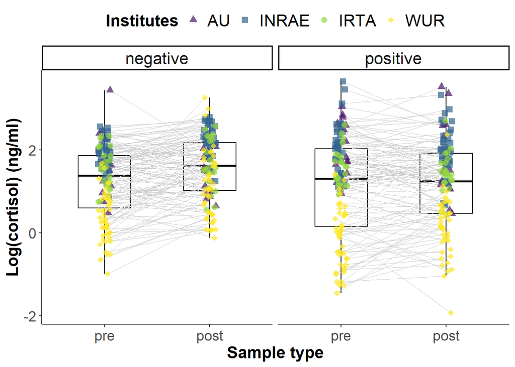

```r
plot
```

```r
png("./plots/cort-log-context-type-institute.png",
    width = 200, height = 180, units = "mm",
    pointsize = 10, res = 600)

plot

dev.off()
```

# Citing R

“All analyses were performed using R Statistical Software (version 4.4.2; R Core Team 2024)”.

Reference: R Core Team (2024). R: A language and environment for statistical computing. R Foundation for Statistical Computing, Vienna, Austria. URL https://www.R-project.org/.

```r
citation()
```

```
  R Core Team (2024). _R: A Language and Environment for Statistical
  Computing_. R Foundation for Statistical Computing, Vienna, Austria.
  <https://www.R-project.org/>.

Ein BibTeX-Eintrag für LaTeX-Benutzer ist

  @Manual{,
    title = {R: A Language and Environment for Statistical Computing},
    author = {{R Core Team}},
    organization = {R Foundation for Statistical Computing},
    address = {Vienna, Austria},
    year = {2024},
    url = {https://www.R-project.org/},
  }

We have invested a lot of time and effort in creating R, please cite it
when using it for data analysis. See also 'citation("pkgname")' for
citing R packages.
```

```r
version$version.string
```

```
[1] "R version 4.4.2 (2024-10-31 ucrt)"
```

```r
citation("kableExtra")
```

```
Um Paket 'kableExtra' in Publikationen zu zitieren, nutzen Sie bitte:

  Zhu H (2024). _kableExtra: Construct Complex Table with 'kable' and
  Pipe Syntax_. R package version 1.4.0,
  <https://CRAN.R-project.org/package=kableExtra>.

Ein BibTeX-Eintrag für LaTeX-Benutzer ist

  @Manual{,
    title = {kableExtra: Construct Complex Table with 'kable' and Pipe Syntax},
    author = {Hao Zhu},
    year = {2024},
    note = {R package version 1.4.0},
    url = {https://CRAN.R-project.org/package=kableExtra},
  }
```

```r
citation("tidyverse")
```

```
Um Paket 'tidyverse' in Publikationen zu zitieren, nutzen Sie bitte:

  Wickham H, Averick M, Bryan J, Chang W, McGowan LD, François R,
  Grolemund G, Hayes A, Henry L, Hester J, Kuhn M, Pedersen TL, Miller
  E, Bache SM, Müller K, Ooms J, Robinson D, Seidel DP, Spinu V,
  Takahashi K, Vaughan D, Wilke C, Woo K, Yutani H (2019). "Welcome to
  the tidyverse." _Journal of Open Source Software_, *4*(43), 1686.
  doi:10.21105/joss.01686 <https://doi.org/10.21105/joss.01686>.

Ein BibTeX-Eintrag für LaTeX-Benutzer ist

  @Article{,
    title = {Welcome to the {tidyverse}},
    author = {Hadley Wickham and Mara Averick and Jennifer Bryan and Winston Chang and Lucy D'Agostino McGowan and Romain François and Garrett Grolemund and Alex Hayes and Lionel Henry and Jim Hester and Max Kuhn and Thomas Lin Pedersen and Evan Miller and Stephan Milton Bache and Kirill Müller and …
    year = {2019},
    journal = {Journal of Open Source Software},
    volume = {4},
    number = {43},
    pages = {1686},
    doi = {10.21105/joss.01686},
  }
```

```r
citation("rstatix")
```

```
Um Paket 'rstatix' in Publikationen zu zitieren, nutzen Sie bitte:

  Kassambara A (2023). _rstatix: Pipe-Friendly Framework for Basic
  Statistical Tests_. R package version 0.7.2,
  <https://CRAN.R-project.org/package=rstatix>.

Ein BibTeX-Eintrag für LaTeX-Benutzer ist

  @Manual{,
    title = {rstatix: Pipe-Friendly Framework for Basic Statistical Tests},
    author = {Alboukadel Kassambara},
    year = {2023},
    note = {R package version 0.7.2},
    url = {https://CRAN.R-project.org/package=rstatix},
  }
```

```r
citation("lmerTest")
```

```
  Kuznetsova A, Brockhoff PB, Christensen RHB (2017). "lmerTest
  Package: Tests in Linear Mixed Effects Models." _Journal of
  Statistical Software_, *82*(13), 1-26. doi:10.18637/jss.v082.i13
  <https://doi.org/10.18637/jss.v082.i13>.

Ein BibTeX-Eintrag für LaTeX-Benutzer ist

  @Article{,
    title = {{lmerTest} Package: Tests in Linear Mixed Effects Models},
    author = {Alexandra Kuznetsova and Per B. Brockhoff and Rune H. B. Christensen},
    journal = {Journal of Statistical Software},
    year = {2017},
    volume = {82},
    number = {13},
    pages = {1--26},
    doi = {10.18637/jss.v082.i13},
  }
```

```r
citation("car")
```

```
  Fox J, Weisberg S (2019). _An R Companion to Applied Regression_,
  Third edition. Sage, Thousand Oaks CA.
  <https://www.john-fox.ca/Companion/>.

Ein BibTeX-Eintrag für LaTeX-Benutzer ist

  @Book{,
    title = {An {R} Companion to Applied Regression},
    edition = {Third},
    author = {John Fox and Sanford Weisberg},
    year = {2019},
    publisher = {Sage},
    address = {Thousand Oaks {CA}},
    url = {https://www.john-fox.ca/Companion/},
  }
```

```r
citation("performance")
```

```
Um Paket 'performance' in Publikationen zu zitieren, nutzen Sie bitte:

  Lüdecke et al., (2021). performance: An R Package for Assessment,
  Comparison and Testing of Statistical Models. Journal of Open Source
  Software, 6(60), 3139. https://doi.org/10.21105/joss.03139

Ein BibTeX-Eintrag für LaTeX-Benutzer ist

  @Article{,
    title = {{performance}: An {R} Package for Assessment, Comparison and Testing of Statistical Models},
    author = {Daniel Lüdecke and Mattan S. Ben-Shachar and Indrajeet Patil and Philip Waggoner and Dominique Makowski},
    year = {2021},
    journal = {Journal of Open Source Software},
    volume = {6},
    number = {60},
    pages = {3139},
    doi = {10.21105/joss.03139},
  }
```

```r
citation("emmeans")
```

```
Um Paket 'emmeans' in Publikationen zu zitieren, nutzen Sie bitte:

  Lenth R (2024). _emmeans: Estimated Marginal Means, aka Least-Squares
  Means_. R package version 1.10.6,
  <https://CRAN.R-project.org/package=emmeans>.

Ein BibTeX-Eintrag für LaTeX-Benutzer ist

  @Manual{,
    title = {emmeans: Estimated Marginal Means, aka Least-Squares Means},
    author = {Russell V. Lenth},
    year = {2024},
    note = {R package version 1.10.6},
    url = {https://CRAN.R-project.org/package=emmeans},
  }
```